# ayush4

**Computer Vision**

**Name: Honey Singh**

**Enrollment No: 12419051622**

**Lab - 4 :** Image Segmentation using K Means

# **OBJECTIVE**

To perform Image segmentation using K means Clustering

# **Reading and Displaying Image**

Reading and displaying an image is the first step before applying any modifications or analysis .To read and display an image in python we first load an image into Python using OpenCV and display it using Matplotlib. We convert the image from OpenCV's default BGR color format to the standard RGB format so that colors display correctly in matplotlib or other libraries.

```python
import numpy as np
import cv2
import matplotlib.pyplot as plt
```

```
(236, 379, 3)
```

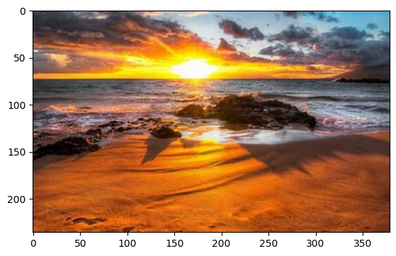

```python
img = cv2.imread(r"H:\My Drive\U.S.A.R\6th Semester\Lab\OIP.jpeg")
img = cv2.cvtColor(img, cv2.COLOR_BGR2RGB)
plt.figure(figsize=(6.5, 5))
plt.imshow(img)
img.shape
```

# **Function for Image Segmentation**

**THEORITICAL CONCEPTS**

**What is Image Segmentation?**

1. Image segmentation is the process of dividing an image into parts or regions.
2. Pixels in the same region look similar in colour, brightness, or texture.
3. Segmentation makes it easier to understand or analyze the image (e.g., find objects, backgrounds, etc).
4. Used For:
   - Object detection (finding people, cars, etc.)
   - Medical imaging (finding tumors in scans)
   - Background removal
   - Robot vision
   - Image compression

**What is Vectorization?**

Vectorization refers to the flattening of pixels. We convert the image into a 2D array where each row is one pixel’s RGB values. Shape becomes: (total_pixels, 3)

Image is a grid of pixels. Normally, an image is a 3D array: height × width × color channels (e.g 600×480×3).

We vectorize the image because algorithms like K-Means expect data as vectors (rows of features). So we reshape the image to feed it into the model.

```python
def image_segmentation(img, k, attempts=10):

    # Reshape image to 2D array of pixels and 3 color values (RGB)
    vectorized_img = img.reshape((-1, 3))
    vectorized_img = np.float32(vectorized_img)

    # Define criteria = (type, max_iter, epsilon)
    criteria = (cv2.TERM_CRITERIA_EPS + cv2.TERM_CRITERIA_MAX_ITER, 10, 1.0)

    # Apply KMeans
    ret, label, center = cv2.kmeans(vectorized_img, k, None, criteria, attempts, cv2.KMEANS_PP_CENTERS)

    # Convert back into uint8 and get result
    center = np.uint8(center)
    res = center[label.flatten()]
    result_image = res.reshape((img.shape))

    # Plot
    plt.figure(figsize=(15, 12))
    plt.subplot(1, 2, 1)
    plt.imshow(img)
    plt.title('Original Image')

    plt.subplot(1, 2, 2)
    plt.imshow(result_image)
    plt.title(f'Segmented Image when K = {k}')
    plt.show()
```

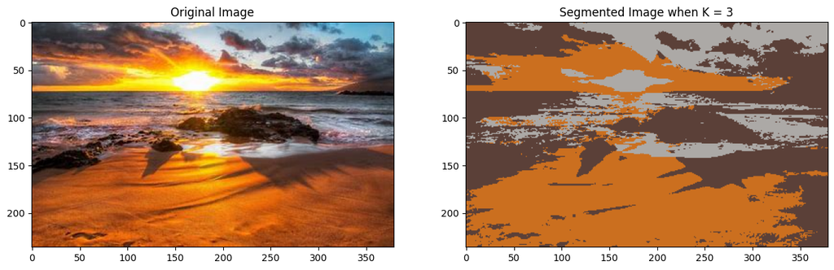

```python
# k=3
image_segmentation(img, 3)
```

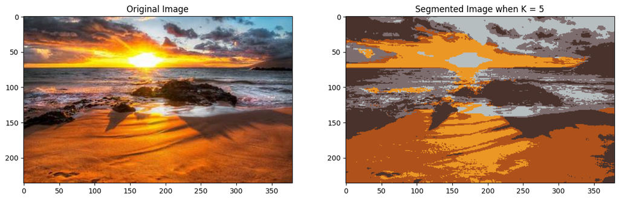

```python
# k=5
image_segmentation(img, 5)
```

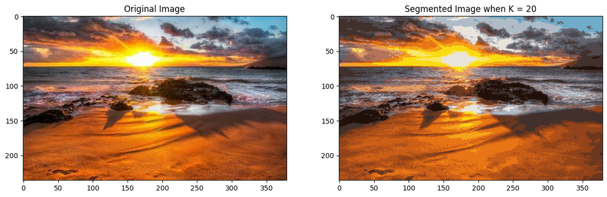

```python
# k=20
image_segmentation(img, 20)
```

# **CONCLUSION**

K-Means clustering effectively segments an image by grouping pixels with similar characteristics. As the value of K increases from 3 to 5 to 20, the segmentation becomes progressively finer, capturing more intricate details and color variations. This demonstrates how higher K values enhance the granularity of the segmented image.